# Prédiction de la valeur foncière de biens immobiliers à Paris

Ensae

18 décembre 2020

# Travail réalisé par

[figure not shown]

# Plan de la présentation

- Base de données
- Modélisation
- Limites et amélirations

# Base de données

Ce projet s’est basé uniquement sur des données disponibles librement sur Internet :

|  | Mode de récupération | Informations sur | Echelle | Année |
| --- | --- | --- | --- | --- |
| [DVF + open](https://cerema.app.box.com/v/dvfplus-opendata) | Site du Cerema | Les transferts immobiliers | Géolocalisée | 2014 - 2019 |
| [Filosofi](https://www.insee.fr/fr/metadonnees/source/serie/s1172) | Site de l’Insee | La situation fiscale et sociale (revenu, type de logement, démographie ..) | Carreau de 200m | 2019 |
| [BPE](https://www.insee.fr/fr/statistiques/3568656) | Site de l’Insee | L’offre de services | Géolocalisée | 2019 |
| [ville-ideale.fr](https://www.ville-ideale.fr/) | Webscraping de ville-ideale.fr | L’avis des internautes concernant leurs quartiers | Arrondissement | Depuis quelques années |

## DVF + open

- Tables mises à disposition par le Céréma :
  - Plusieurs tables liées par un identifiant `idmutation`
  - Tables contenant des informations sur la localisation des biens (Polygon), d’autres sur la valeur … (table `mutation`) –> Fusion de ces tables
- Plus de 60 variables : beaucoup sont similaires
- Base avec des incohérences.
  - Exemple : un bien de 27 m² à 10 000.
- Définition du champ spatial (Paris) et du type de bien (appartement)

## DVF + open

[interactive chart not shown]

## Filosofi

- Tables mises à disposition par l’Insee :
- Information sur le niveau de vie, la démographie, le tissu immobilier à une échelle très locale (carreaux de 200m)
- Problème : pas de clef *a priori* pour faire le lien entre la position du bien et le carreau.
- Solution : vérifier dans quel carreau appartient chaque point –> Chronophage

## Filosofi

[interactive chart not shown]

## BPE

- Tables mises à disposition par l’Insee
- Informations sur le nombre de services disponibles par commune
  - Répartis en plus de 130 catégories
- Certains services sont géolocalisables :
  - Variable indiquant la qualité de la localisation : `Qualite_X_Y`
  - 95% de bonne qualité à Paris

## BPE

[interactive chart not shown]

## ville-ideale.fr

- Site proposant aux internautes de noter leurs quartiers
- Webscrap

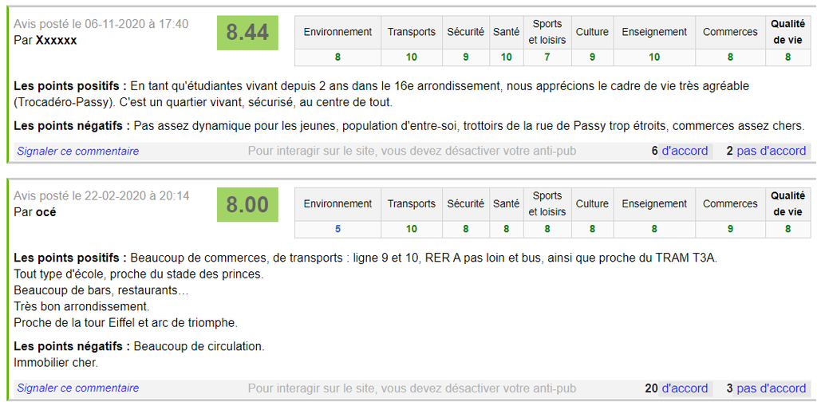

# Modélisation

## SVR (Support Vector Regression)

- Sélection des variables avec la méthode Lasso : 33 variables sélectionnées
- Noyau choisi : gaussien
- Fine tuning : RandomizedSearchCV
- RMSE : 205 309

## RandomForest

- Sélection des variables *à la main*
- Fine tuning par GridSearchCV
- RMSE 145 325

## XGBoost

- Log transformations des données
- Deux types de modèles : XGB et LGB
- Sélection des variables avec Lasso et avec un *random forest naïf*
- Fine tuning : RandomizedSearchCV
- Meilleur modèle : LGB avec une sélection Lasso
- RMSE : 140 786

# Limites et améliorations

## DVF + open :

- Version open source limitée par rapport à la version complète DV3F (version réservée qu’à certains acteurs)
  - Informations sur l’ancienneté du bien, l’acheteur et le vendeur disponibles dans DV3F.
- Peu de variables de la table ont été utilisée lors de la modélisation.
- Information à une date donnée alors que les mutations ont lieu entre 2014 et 2019

## Ville-ideale.fr

- Notes données à l’arrondissement : les notes risquent de ne rien apporter en plus que la variable `arrondissement`.
- Exploiter les commentaires des usagers par arrondissement avec des modèles d’analyse de sentiments par exemple.

## BPE

- Utiliser la distance `à pied` plutôt que la distance euclidiennee.
- Calculer la distance moyenne des *n* premiers services autour du bien immobilier
- Utiliser des variables comme `nombre_de_type_service` dans un rayon de *n* km
  - Problème : comment choisir *n* ?
- Quid des gros pourvoyeurs d’emploi franciliens ?

## BPE

- Non prise en compte de la proximité à une station de métro (quelle ligne ?)
- Variables utilisées peu utiles en réalité pour la prédiction.
- Information à une date donnée alors que les mutations ont lieu entre 2014 et 2019

## Limites générales

- Temps d’entrainement
  - Solution : programmation GPU mais pas dispo sur scikit learn
- Résultats pas exceptionnels
- Manque de variables liées aux biens
- Données fournies par le Céréma assez brutes sans traitement

## Limites générales

- *Ceteris paribus*, le prix des biens augmente d’année en année.
- Nous avons supposé qu’il s’agit d’inflation
- Mais certains facteurs exogènes peuvent modifier le comportement des acheteurs/vendeurs :
  - une politique fiscale visant à pousser les ménages à acheter des biens immobiliers (ex: loi Pinel 2015)
  - une changement de mode de consommation des biens immobiliers (ex: Airbnb)